# Análise de Sentimentos SUS

Henrique Silva

10/10/2020

# Computação para Análise de Dados

## Introdução

### Introdução

Para a maioria dos brasileiros, o atendimento médico do SUS é a única opção de busca por saúde quando necessário, pelo fato de apenas uma pequena parte da população ter acesso a planos de saúde particular, ou condições para pagar por consultas em médicos particulares.

A abordagem consistirá em separar os tweets coletados pelos meses de cada um, realizar análises de sentimentos por período, identificar palavras mais frequentes em cada período para positivos e negativos. Para essas palavras, identificar quais os termos de temas mais relevantes, para identificar também qual o sentimento da população nesses temas relacionados diretamente ao SUS. No final, serão gerados gráficos que para facilitar a visualização destes dados.

## Pacotes Requeridos

```r
library(tm)         # Será utilizado para análise de sentimentos.
library(wordcloud)  # Será utilizado para gerar nuvens de palavras com as palavras mais frequentes no dataset.
library(syuzhet)    # Será utilizado para realizar a classificação do sentimento dos textos.
library(stringr)    # Será utilizado para limpeza dos dados.
library(stringi)    # Será utilizado para limpeza dos dados.
library(readr)      # Será utilizado para limpeza e formatação dos dados.
library(dplyr)      # Será utilizado para formatação de visualização dos dados
library(reshape)    # Será utilizado para formatar os dados para a nuvem de palavras.
library(DT)         # Será utilizado para visualização em tabelas
```

## Preparação dos Dados

### Coleta dos dados

Os dados foram coletados em outubro de 2020, com a utilização da API [Twint](https://github.com/twintproject/twint) através dos comandos cmd que está disponpivel neste [arquivo python notebook no GitHub](https://github.com/henriquefps/SUS-Sentiment-Analysis/blob/master/SUS_Saude/Tweets_BD.ipynb) do projeto. Sobre esta API, é importante ressaltar que ela está sempre sendo atualizada, e dependendo do momento em que o teste seja realizado, ela pode estar indisponível. Com a API, os tweets foram buscados entre dezembro de 2019 e setembro de 2020, e com limite de 10 mil tweets por mês. Após coletados, os tweets salvos como CSV no ambiente. Caso seja executado em um ambiente python notebook online, o código, após a coleta, salva os arquivos na raiz do Google Drive pela api “gdrive”.

Para a coleta, escolheu-se pesquisar por tweets com o termo “Saúde SUS”. Um problema encontrado quando pesquisando apenas pelo termo “SUS” foi a quantidade de tweets em espanhol não relacionadas ao tema do sistema de saúde brasileiro. Isso ocorreu mesmo filtrando apenas por tweets em português “pt-BR”, provavelmente por alguma dificuldade do próprio Twiites em classificar estes tweets retornados como espanhol. A escolha do termo “Saúde SUS” restringe um pouco nossa pesquisa, porém garante que irá retornar tweets onde as duas palavras aparecem, e que o que será retornado tem relação com o tema do trabalho, sem acrescentar viés na busca.

Após coletados, chamou atenção que pouquíssimos tweets tinham localização disponível. Na base de dados que foi montada para este projeto, dos mais de 70 mil tweets coletados, nenhum possui dados de localização, tornando inviável análises considerando este tipo de dados.

Nesta execução serão utilizados 2500 tweets por mês, totalizando 25 mil tweets dos meses de dezembro 2019 a setembro 2020.

#### Exemplo de chamada Twint

```bash
twint -s "Saúde SUS" --since 2019-12-01 --until 2020-01-01 --limit 10000 --lang "pt-BR" -fr -pc 1 -o dec2019 --csv
```

### Carregando e visualizando de dados coletados

```r
tweets <- read.csv("https://raw.githubusercontent.com/henriquefps/SUS-Sentiment-Analysis/master/new_tweetsdb.csv", encoding= "UTF-8")

# tweets <- read.csv("new_tweetsdb.csv", encoding = "UTF-8")

# Formatar data dos tweets de yyyy-MM-dd para yyyy-MM, ignorando o dia
tweets$datef <- str_extract(tweets$date, "[0-9]{4}-[0-9]{2}")

# Tweets coletados por mês com o termo "Saúde SUS"
datatable(tweets %>% group_by(datef) %>% count(name = "Tweets"))
```

|  | datef | Tweets |
| --- | --- | --- |
| 1 | 2019-12 | 4136 |
| 2 | 2020-01 | 3783 |
| 3 | 2020-02 | 4443 |
| 4 | 2020-03 | 10085 |
| 5 | 2020-04 | 10066 |
| 6 | 2020-05 | 10084 |
| 7 | 2020-06 | 6893 |
| 8 | 2020-07 | 6363 |
| 9 | 2020-08 | 8233 |
| 10 | 2020-09 | 7746 |

```r
# Variáveis disponíveis na chamada
colnames(tweets)
```

```
##  [1] "X"               "id"              "conversation_id" "created_at"
##  [5] "date"            "time"            "timezone"        "user_id"
##  [9] "username"        "name"            "place"           "tweet"
## [13] "language"        "mentions"        "urls"            "photos"
## [17] "replies_count"   "retweets_count"  "likes_count"     "hashtags"
## [21] "cashtags"        "link"            "retweet"         "quote_url"
## [25] "video"           "thumbnail"       "near"            "geo"
## [29] "source"          "user_rt_id"      "user_rt"         "retweet_id"
## [33] "reply_to"        "retweet_date"    "translate"       "trans_src"
## [37] "trans_dest"      "datef"
```

```r
# Exemplo de registro
head(tweets, n=1)
```

```
##   X                  id     conversation_id              created_at       date
## 1 1 1212151636019294209 1212149835962425347 2019-12-31 23:20:45 UTC 2019-12-31
##       time timezone    user_id        username             name place
## 1 23:20:45        0 3435000821 movavantebrasil M. Avante Brasil
##                                                                                                                                                                                                                                          tweet
## 1 Parte dos recursos (45%) é direcionada para o Sistema Único de Saúde (SUS).\nToffoli acrescentou que o objetivo da Medida Provisória suspensa pela Corte era “semelhante” ao que foi pretendido com a edição da norma com os novos valores +
##   language mentions urls photos replies_count retweets_count likes_count
## 1       pt       []   []     []             1              2           2
##   hashtags cashtags
## 1       []       []
##                                                             link retweet
## 1 https://twitter.com/MovAvanteBrasil/status/1212151636019294209      NA
##   quote_url video thumbnail near geo source user_rt_id user_rt retweet_id
## 1               0             NA  NA     NA         NA      NA         NA
##                                                   reply_to retweet_date
## 1 {'user_id': '3435000821', 'username': 'MovAvanteBrasil'}           NA
##   translate trans_src trans_dest   datef
## 1        NA        NA         NA 2019-12
```

```r
# Tweets coletados com localização
length(which(!is.na(tweets$geo)))
```

```
## [1] 0
```

### Constantes

Declaração de algumas constantes necessárias no código.

```r
# Meses no período de pesquisa
months <- c("Dez 19", "Jan 20", "Fev 20", "Mar 20", "Abr 20", "Mai 20", "Jun 20", "Jul 20", "Ago 20", "Set 20")

# Abreviações de StopWords informais não contempladas em stopwords("portuguese")
extra_stpwords <- c("pra", "pro", "né", "tá", "vcs", "tô", "aí")

# Tradução das colunas de sentimentos do NRC Sentiment
sent_labels <- c("Raiva", "Antecipação", "Nojo", "Medo", "Alegria",
"Tristeza", "Surpesa", "Confiança", "Negativo", "Positivo", "Neutro")

#Colunas de sentimentos com relevância selecionadas para o projeto
col_sents <- c(1, 3, 4, 5, 6, 8)

# Número de tweets a considerar por mês
ntweets <- 2500

# Limite das nuvens de palavras
ncloud <- 500
```

### Funções

A ação get_nrc_sentiment da biblioteca syhuzet retorna sentimentos analizado por frases contidas no texto. Sendo assim, um tweet com 5 frases terá 5 análises de sentimento positivo ou negativo. Considerando essa funcionalidade da biblioteca, na ação get_sentiment, foi implementada uma comparação para definir se a classe do tweet é positiva(mais frases positivas que negativas), negativa(mais classes negativas que positivas) ou neutro(mesma quantidade de frases negativas e positivas).

```r
textclean1 <- function(text_list){
  aux <- text_list
  removeURL <- function(x) gsub("http[^[:space:]]*", "", x)
  aux <-  readr::parse_character(aux, locale = readr::locale('pt'))
  aux <- sapply(aux, function(x) stri_trans_tolower(x,'pt')) # Por tudo em letras minúsculas
  aux <- gsub("<[Uu]\\+[a-zA-Z0-9]*>", "",  aux); # Remover Emojis
  aux <- gsub("(RT|via)((?:\\b\\W*@\\w+)+)", "",  aux) # Remover informações de retweet
  aux <- str_replace(aux,"RT @[a-z,A-Z]*: ","") # Remover informações de retweet
  aux <- gsub("@\\w+", "", aux) # Remover marcações @username
  aux <- removeURL(aux) # Remover links
  aux <- gsub(x = aux, pattern = "\n", replacement = " ") # Susbstitur \n por espaços
  aux <- gsub(x = aux, pattern = '\\"', replacement = ' ') # Substituir " por vazio
  aux <- gsub("[^%[:alnum:][:blank:]!?]", "", aux)  # Remover caracteres que não são % ou alphanuméricos
  aux <- gsub(x =  aux, pattern = "saude", "saúde") # Substituir saude por saúde
  aux <- gsub(x =  aux, pattern = "saãde", "saúde") # Substituir saãde, um problema de encoding encontrado, por saúde
  return(aux)
}

get_sentiment <- function(text_listf, title="Sentimentos"){
  s <- get_nrc_sentiment(text_listf, language = "portuguese") #Sentimentos em PT
  s$neutral <- (s$positive == s$negative) > 0
  s$positive <- (s$positive > s$negative) > 0
  s$negative <- (s$positive == 0 & s$neutral == 0) > 0
  colnames(s) <- sent_labels
  return(s)
}

removeNumPunct <- function(x){
  x = gsub("[^[:alnum:]]", " ",x)
  return (stripWhitespace(x))
}

#Tokenizando
BigramTokenizer <- function(x){
  return(unlist(lapply(ngrams(words(x), 2), paste, collapse = " "), use.names = FALSE))
}

get_freq <- function(tp, cloud_max_words){
  positive_texts <- select(filter(tp, label=="Positivo"), textf)
  negative_texts <- select(filter(tp, label=="Negativo"), textf)

  #Unindo documentos textuais
  data_pos_string <- paste(positive_texts, sep = " ", collapse = " ")
  data_neg_string <- paste(negative_texts, sep = " ", collapse = " ")

  #Criando Matriz de Termos do Documento
  classes = c("Positivo", "Negativo")
  corpus_data <- removeNumPunct(c(data_pos_string, data_neg_string))
  corpus <- VCorpus(VectorSource(corpus_data))
  corpus <- tm_map(corpus, removeNumbers)
  corpus <- tm_map(corpus, removeWords, c(stopwords("portuguese"), extra_stpwords))
  tdm <- TermDocumentMatrix(corpus, control = list(tokenize = BigramTokenizer))
  tdm_clean <- as.matrix(removeSparseTerms(tdm, 0.8))
  colnames(tdm_clean) <- classes

  #Gerando nuvem de palavras
  comparison.cloud(tdm_clean,max.words=cloud_max_words,random.order=FALSE,scale=c(2,.3), title.size=1.4, colors = c("#119911", "red"))
}

get_labels <- function(sentiment){
  aux <- sentiment
  aux$label <- "Neutro"
  aux[aux$Negativo == 1,]$label <- "Negativo"
  aux[aux$Positivo == 1,]$label <- "Positivo"
  return(aux$label)
}
```

### Limpar dados

Para a limpeza dos dados, como nosso objetivo é realizar analise de sentimentos, é importante remover as marcações de outras pessoas, os “@username”. Também precisamos remover emojis, que no CSV estão no formato 🇨 e remover links. Neste projeto estaremos considerando todas essas informações como ruído, porém acredito ser possível considerar emojis nas emoções em uma implementação própria do algoritmo de classificação de sentimentos.

Também foi realizada uma formaração na data-hora do tweet, para considerar apenas o mês e ano em que o tweet foi feito, desconsiderando o dia e hora de publicação.

Neste projeto estamos utilizando apenas as informações de data e texto dos tweets.

```r
# Selecionar colunas para análise
tweets <- tweets %>% select(datef, tweet)

# Nova coluna com tweets formatados
tweets$textf <- textclean1(tweets$tweet)
```

### Exemplo de textos formatados

```r
# Exemplo de dados formatados
datatable(head(tweets %>% select(tweet, textf), n = 1))
```

|  | tweet | textf |
| --- | --- | --- |
| 1 | Parte dos recursos (45%) é direcionada para o Sistema Único de Saúde (SUS). Toffoli acrescentou que o objetivo da Medida Provisória suspensa pela Corte era “semelhante” ao que foi pretendido com a edi… | parte dos recursos 45% é direcionada para o sistema único de saúde sus toffoli acrescentou que o objetivo da medida provisória suspensa pela corte era semelhante ao que foi pretendido com a edição da … |

### Análise de Sentimentos

```r
# Separar dataset por meses
tp1 <- tweets[tweets$datef == "2019-12",][1:ntweets,]
tp2 <- tweets[tweets$datef == "2020-01",][1:ntweets,]
tp3 <- tweets[tweets$datef == "2020-02",][1:ntweets,]
tp4 <- tweets[tweets$datef == "2020-03",][1:ntweets,]
tp5 <- tweets[tweets$datef == "2020-04",][1:ntweets,]
tp6 <- tweets[tweets$datef == "2020-05",][1:ntweets,]
tp7 <- tweets[tweets$datef == "2020-06",][1:ntweets,]
tp8 <- tweets[tweets$datef == "2020-07",][1:ntweets,]
tp9 <- tweets[tweets$datef == "2020-08",][1:ntweets,]
tp10 <- tweets[tweets$datef == "2020-09",][1:ntweets,]

#Análise de sentimentos de cada mês
tp1.s <- get_sentiment(tp1$textf)
tp1$label <- get_labels(tp1.s)

tp2.s <- get_sentiment(tp2$textf)
tp2$label <- get_labels(tp2.s)

tp3.s <- get_sentiment(tp3$textf)
tp3$label <- get_labels(tp3.s)

tp4.s <- get_sentiment(tp4$textf)
tp4$label <- get_labels(tp4.s)

tp5.s <- get_sentiment(tp5$textf)
tp5$label <- get_labels(tp5.s)

tp6.s <- get_sentiment(tp6$textf)
tp6$label <- get_labels(tp6.s)

tp7.s <- get_sentiment(tp7$textf)
tp7$label <- get_labels(tp7.s)

tp8.s <- get_sentiment(tp8$textf)
tp8$label <- get_labels(tp8.s)

tp9.s <- get_sentiment(tp9$textf)
tp9$label <- get_labels(tp9.s)

tp10.s <- get_sentiment(tp10$textf)
tp10$label <- get_labels(tp10.s)
```

## Análise Exploratória

### Análises

#### Mês a Mês

```r
# Agrupar dados para gráficos
df <- matrix(c(colSums(tp1.s>0),colSums(tp2.s>0),colSums(tp3.s>0),colSums(tp4.s>0),colSums(tp5.s>0),colSums(tp6.s>0),colSums(tp7.s>0),colSums(tp8.s>0),colSums(tp9.s>0),colSums(tp10.s>0)), nrow = 11, ncol = 10, byrow = F)
```

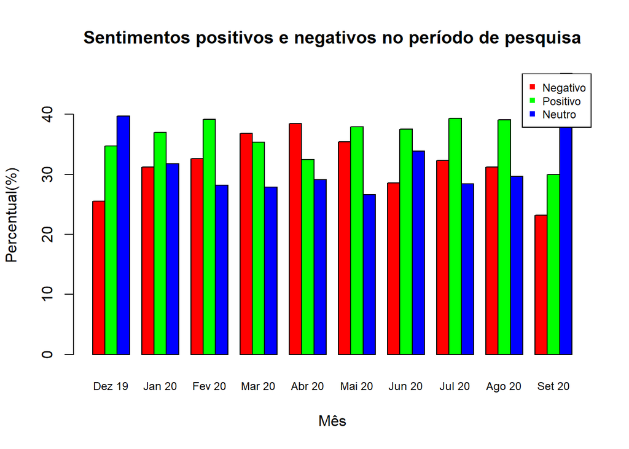

```r
col_posneg <- c(9:11)
pos_neg <- df[col_posneg,]
aux <- pos_neg

#Calcular percentual por classe
for (i in c(1:length(pos_neg[1,]))) {
  for (j in c(1:length(pos_neg[,1]))) {
    pos_neg[j,i] <- (pos_neg[j,i]/ sum(aux[,i]))*100
  }
}
sent <- df[c(col_sents),]

barplot(pos_neg, col=rainbow(length(pos_neg[,1])), names.arg = months, beside = T, xlab = "Mês", ylab="Percentual(%)", main= "Sentimentos positivos e negativos no período de pesquisa", cex.names = 0.75)
legend("topright", pch = 15, col = rainbow(length(pos_neg[,1])), sent_labels[col_posneg], cex = 0.75)
```

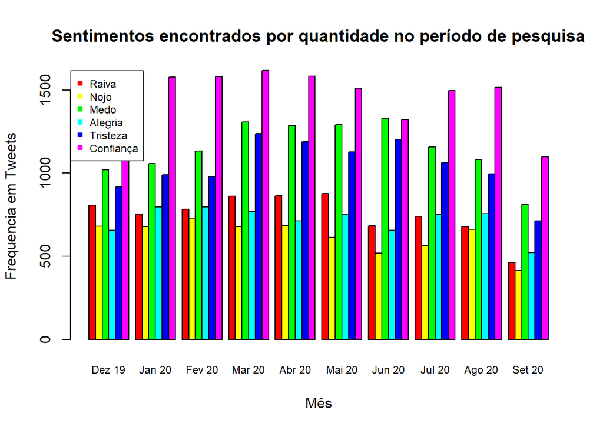

```r
sent <- df[c(col_sents),]

barplot(sent, col=rainbow(length(sent[,1])), names.arg = months, beside = T, xlab = "Mês", ylab="Frequencia em Tweets", main= "Sentimentos encontrados por quantidade no período de pesquisa", cex.names = 0.75)
legend("topleft", pch = 15, col = rainbow(length(sent[,1])), sent_labels[col_sents], cex = 0.75)
```

##### Nuvens de Palavras

###### Dezembro 2019

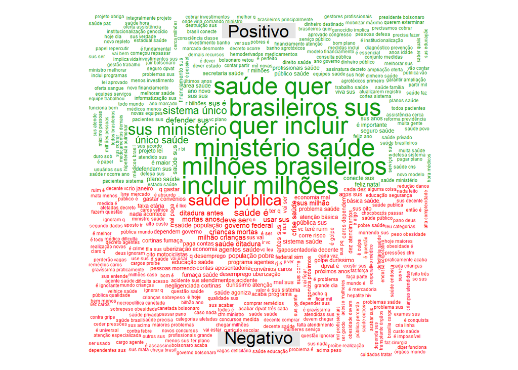

```r
get_freq(tp1, ncloud)
```

###### Janeiro 2020

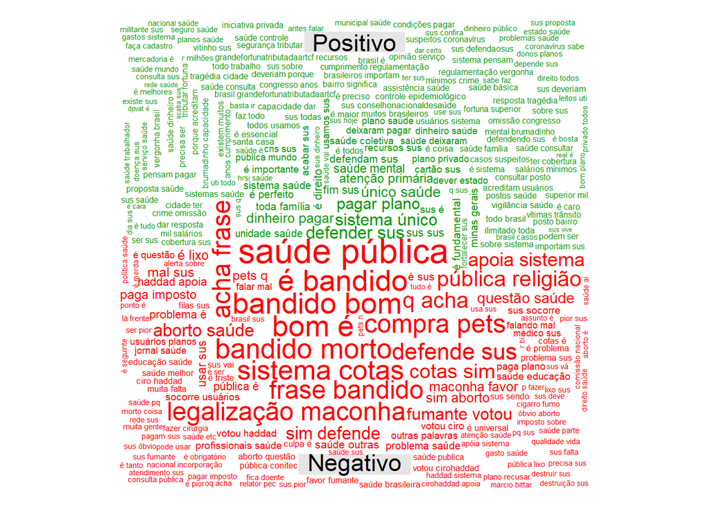

```r
get_freq(tp2, cloud_max_words = ncloud)
```

###### Fevereiro 2020

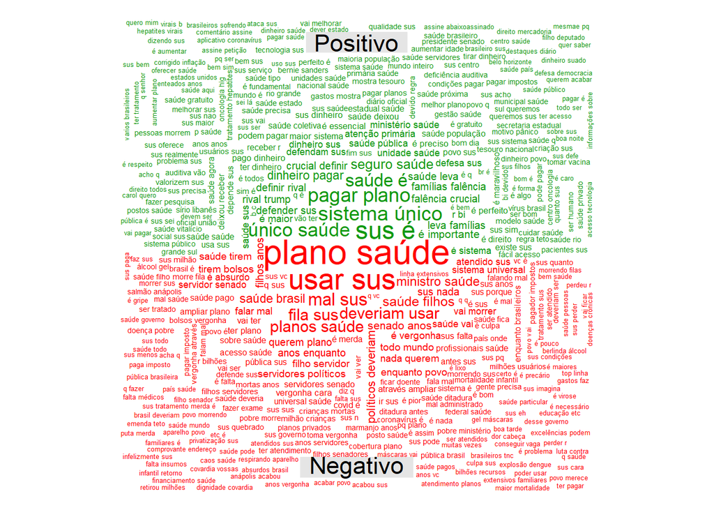

```r
get_freq(tp3, cloud_max_words = ncloud)
```

###### Março 2020

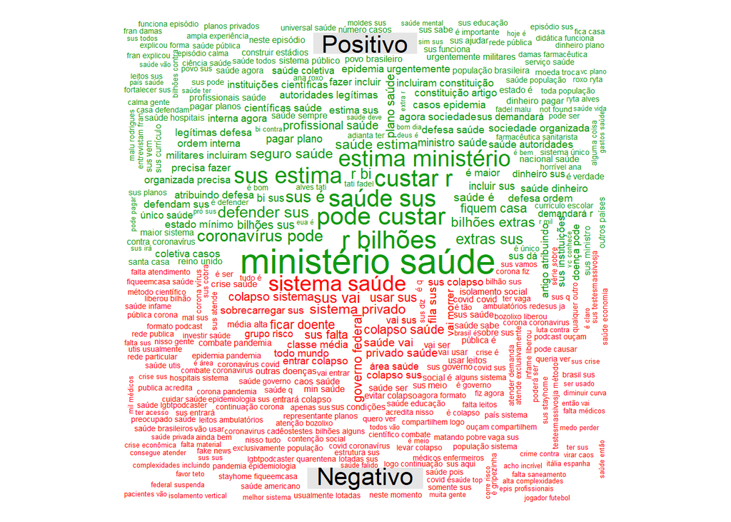

```r
get_freq(tp4, cloud_max_words = ncloud)
```

###### Abril 2020

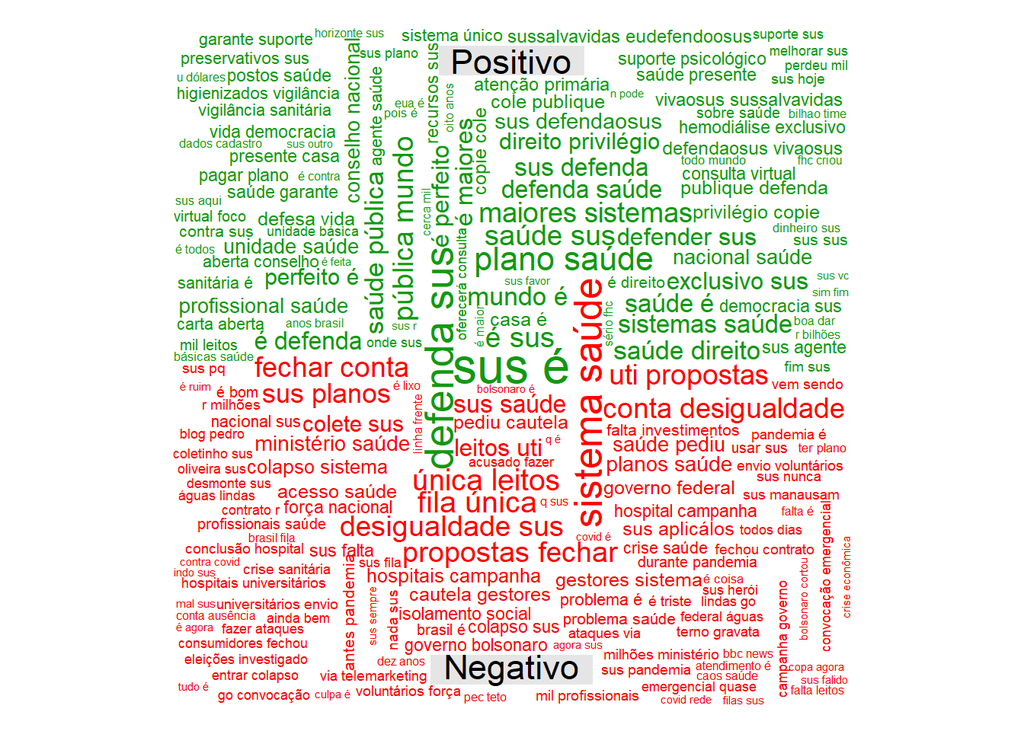

```r
get_freq(tp5, cloud_max_words = ncloud)
```

###### Maio 2020

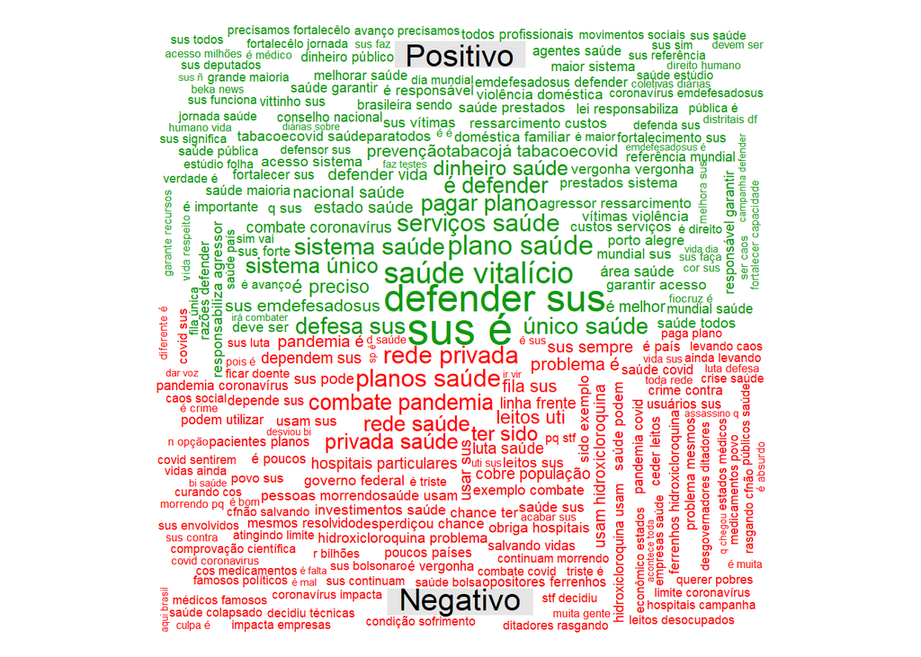

```r
get_freq(tp6, cloud_max_words = ncloud)
```

###### Junho 2020

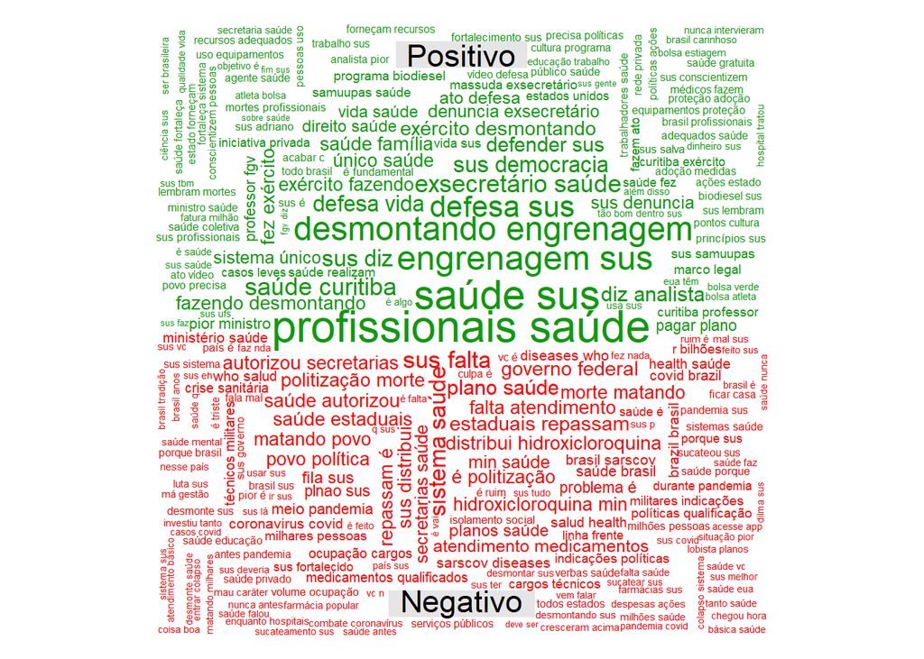

```r
get_freq(tp7, cloud_max_words = ncloud)
```

###### Julho 2020

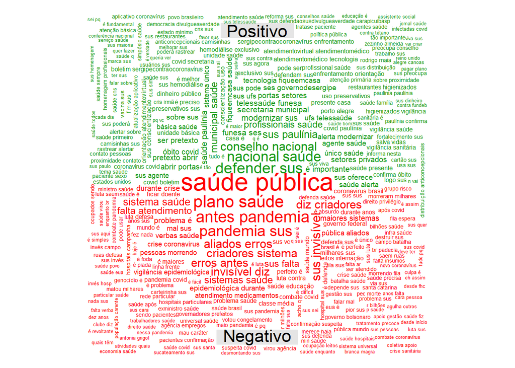

```r
get_freq(tp8, cloud_max_words = ncloud)
```

###### Agosto 2020

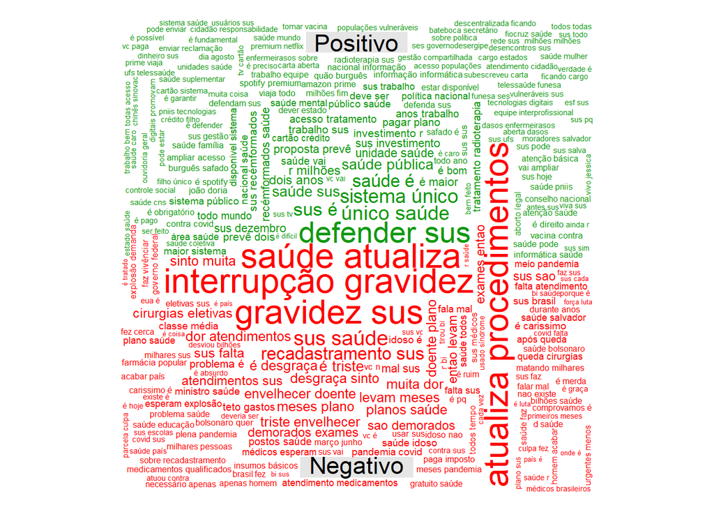

```r
get_freq(tp9, cloud_max_words = ncloud)
```

###### Setembro 2020

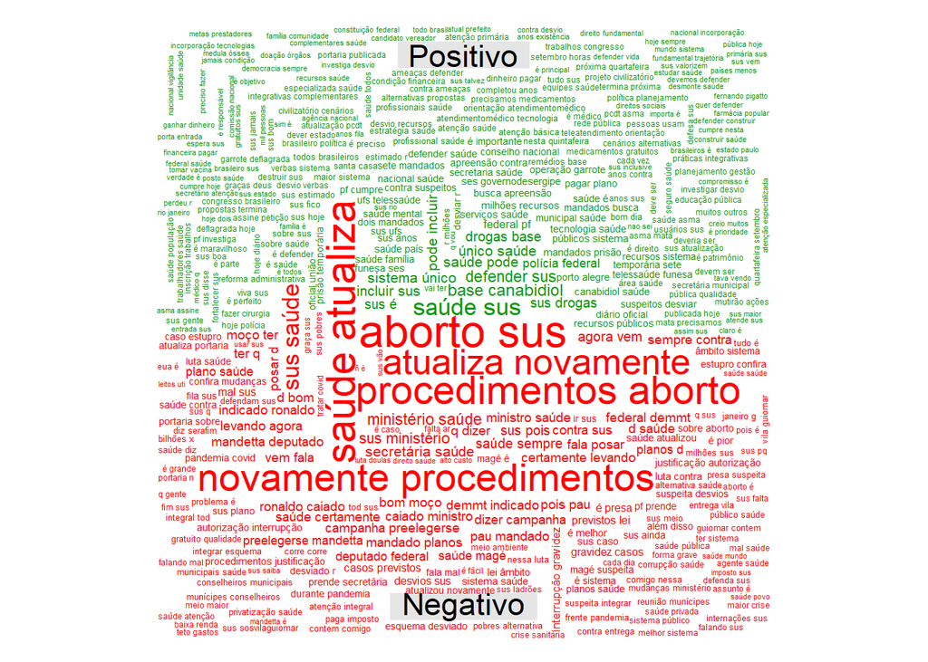

```r
get_freq(tp10, cloud_max_words = ncloud)
```

##### Análise dos dados

Acompanhando a evolução do gráfico de sentimentos positivos e negativos, é possível perceber que nos meses que se antecederam a pandemia, ou seja, até fevereiro de 2020, O percentual de tweets positivos com relação ao tema do SUS manteve-se constantemente acima dos tweets negativos.

|  | periodo | termos | contexto |
| --- | --- | --- | --- |
| 1 | Dez 19 | 'quer incluir', 'milhões brasileiros' | Programa Previne Brasil quer incluir 50 milhões de brasileiros no SUS |
| 2 | Jan 20 | 'defende sus', 'compra pets' | Foi encontrada uma corrente de rede social sobre vários temas, incluindo defesa do sus, onde a maioria se mostra a favor |

No mês de março, primeiro mês da pandemia, foi a primeira vez no período de análise em que a quantidade de tweets negativos foi proporcionalmente maior que o de tweets positivos. Começando nesse mês, e durante os próximos 4 meses de análise, foram registrado os picos dos sentimentos “Medo” nos tweets analisados. Observando também as nuvens de palavras de março 2020 e abril de 2020, podemos encontrar alguns dos motivos para esse pico no medo dos usuários sobre o tema do SUS.

Em março falou-se muito do custo financeiro da pandemia no orçamento do SUS, além do possível colapso do sistema de saúde com a sobrecarga de leitos. Já em abril comentou-se menos do impacto financeiro, porém a questão da desigualdade social ao acesso a saúde também aparece acrescentada aou outros como fator que infuenciam os sentimentos de “Medo” e “Tristeza”.

No mês de maio o sentimento a proporção de sentimentos voltou a tender ligeiramente para o positivo, com o incentivo de termos como o defenda o sus, movimento que apareceu em destaque pela primeira vez em abril, e se manteve em destaque com defesa sus e defender sus pelo restante do período de análise.

#### Pontos de interesse

##### Governo Federal

Percebeu-se que o Governo federal foi um dos tópicos que mais apareceu em tweets negativos

```r
gov_fed <- rbind(tp1,tp2,tp3,tp4,tp5,tp6,tp7,tp8,tp9,tp10)
gov_fed <- gov_fed[grep(gov_fed$textf, pattern = "(governo)|(federal)"),]
```

Quantidade de tweets com governo federal

```r
length(gov_fed$textf)
```

```
## [1] 1653
```

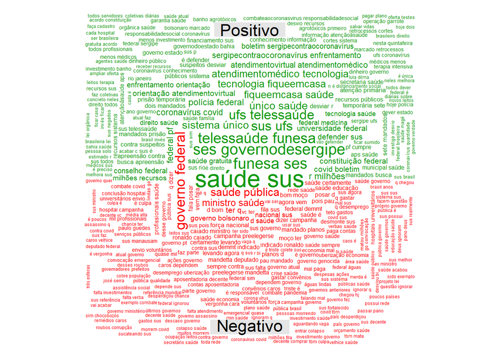

```r
get_freq(gov_fed, cloud_max_words = ncloud)
```

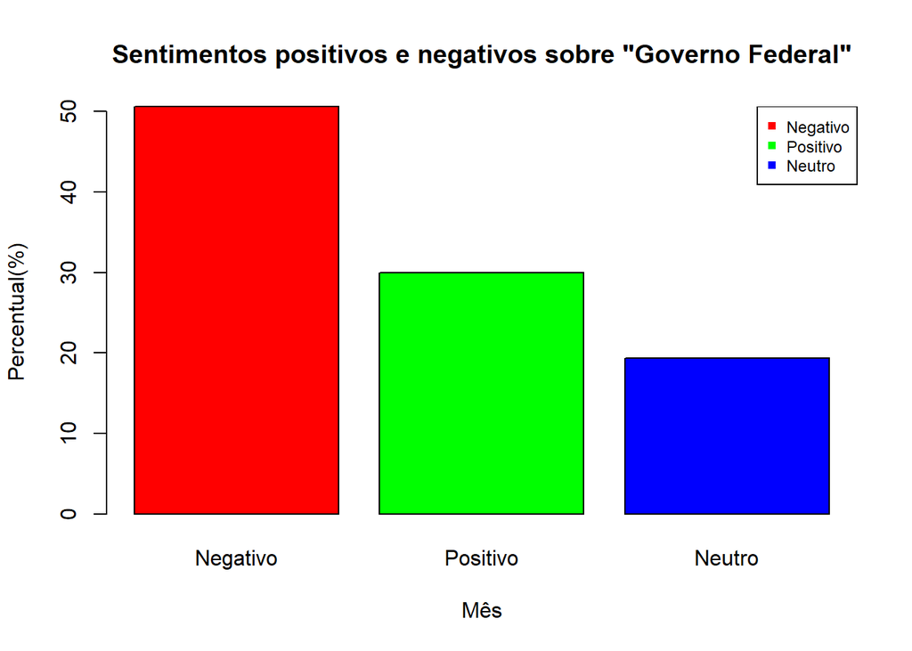

```r
tp_govf <- get_sentiment(gov_fed$textf)
df_gov <- matrix(c(colSums(tp_govf>0)), nrow = 11, ncol = 1, byrow = F)

col_posneg <- c(9:11)
pos_neg <- df_gov[col_posneg,]
aux <- pos_neg

for (j in c(1:length(pos_neg))) {
  pos_neg[j] <- (pos_neg[j]/ sum(aux))*100
}

sent <- df_gov[c(col_sents),]

barplot(pos_neg, col=rainbow(length(pos_neg)), names.arg = c("Negativo","Positivo", "Neutro"), beside = T, xlab = "Mês", ylab="Percentual(%)", main= "Sentimentos positivos e negativos sobre \"Governo Federal\"")
legend("topright", pch = 15, col = rainbow(length(pos_neg)), sent_labels[col_posneg], cex = 0.75)
```